# Lab 3 Phillips

## Wine dataset

We will be looking at a dataset that consists of wine statistics by wine category.

(1) Modify the following to see the head of the wine data file. (You should specify the relative path of the data.)

```python
data =!more winedata.txt
data
```

```
['#The next 14 lines are the variable names, then the remaining lines are the data in csv',
 'Wine Class',
 'Alcohol',
 'Malic acid',
 'Ash',
 'Alcalinity of ash',
 'Magnesium',
 'Total phenols',
 'Flavanoids',
 'Nonflavanoid phenols',
 'Proanthocyanins',
 'Color intensity',
 'Hue',
 'OD280/OD315 of diluted wines',
 'Proline            ',
 '1,14.23,1.71,2.43,15.6,127,2.8,3.06,.28,2.29,5.64,1.04,3.92,1065',
 '1,13.2,1.78,2.14,11.2,100,2.65,2.76,.26,1.28,4.38,1.05,3.4,1050',
 '1,13.16,2.36,2.67,18.6,101,2.8,3.24,.3,2.81,5.68,1.03,3.17,1185',
 '1,14.37,1.95,2.5,16.8,113,3.85,3.49,.24,2.18,7.8,.86,3.45,1480',
 '1,13.24,2.59,2.87,21,118,2.8,2.69,.39,1.82,4.32,1.04,2.93,735',
 '1,14.2,1.76,2.45,15.2,112,3.27,3.39,.34,1.97,6.75,1.05,2.85,1450',
 '1,14.39,1.87,2.45,14.6,96,2.5,2.52,.3,1.98,5.25,1.02,3.58,1290',
 '1,14.06,2.15,2.61,17.6,121,2.6,2.51,.31,1.25,5.05,1.06,3.58,1295',
 '1,14.83,1.64,2.17,14,97,2.8,2.98,.29,1.98,5.2,1.08,2.85,1045',
 '1,13.86,1.35,2.27,16,98,2.98,3.15,.22,1.85,7.22,1.01,3.55,1045',
 '1,14.1,2.16,2.3,18,105,2.95,3.32,.22,2.38,5.75,1.25,3.17,1510',
 '1,14.12,1.48,2.32,16.8,95,2.2,2.43,.26,1.57,5,1.17,2.82,1280',
 '1,13.75,1.73,2.41,16,89,2.6,2.76,.29,1.81,5.6,1.15,2.9,1320',
 '1,14.75,1.73,2.39,11.4,91,3.1,3.69,.43,2.81,5.4,1.25,2.73,1150',
 '1,14.38,1.87,2.38,12,102,3.3,3.64,.29,2.96,7.5,1.2,3,1547',
 '1,13.63,1.81,2.7,17.2,112,2.85,2.91,.3,1.46,7.3,1.28,2.88,1310',
 '1,14.3,1.92,2.72,20,120,2.8,3.14,.33,1.97,6.2,1.07,2.65,1280',
 '1,13.83,1.57,2.62,20,115,2.95,3.4,.4,1.72,6.6,1.13,2.57,1130',
 '1,14.19,1.59,2.48,16.5,108,3.3,3.93,.32,1.86,8.7,1.23,2.82,1680',
 '1,13.64,3.1,2.56,15.2,116,2.7,3.03,.17,1.66,5.1,.96,3.36,845',
 '1,14.06,1.63,2.28,16,126,3,3.17,.24,2.1,5.65,1.09,3.71,780',
 '1,12.93,3.8,2.65,18.6,102,2.41,2.41,.25,1.98,4.5,1.03,3.52,770',
 '1,13.71,1.86,2.36,16.6,101,2.61,2.88,.27,1.69,3.8,1.11,4,1035',
 '1,12.85,1.6,2.52,17.8,95,2.48,2.37,.26,1.46,3.93,1.09,3.63,1015',
 '1,13.5,1.81,2.61,20,96,2.53,2.61,.28,1.66,3.52,1.12,3.82,845',
```

[output cut: 138 more lines]

```
 '3,12.96,3.45,2.35,18.5,106,1.39,.7,.4,.94,5.28,.68,1.75,675',
 '3,13.78,2.76,2.3,22,90,1.35,.68,.41,1.03,9.58,.7,1.68,615',
 '3,13.73,4.36,2.26,22.5,88,1.28,.47,.52,1.15,6.62,.78,1.75,520',
 '3,13.45,3.7,2.6,23,111,1.7,.92,.43,1.46,10.68,.85,1.56,695',
 '3,12.82,3.37,2.3,19.5,88,1.48,.66,.4,.97,10.26,.72,1.75,685',
 '3,13.58,2.58,2.69,24.5,105,1.55,.84,.39,1.54,8.66,.74,1.8,750',
 '3,13.4,4.6,2.86,25,112,1.98,.96,.27,1.11,8.5,.67,1.92,630',
 '3,12.2,3.03,2.32,19,96,1.25,.49,.4,.73,5.5,.66,1.83,510',
 '3,12.77,2.39,2.28,19.5,86,1.39,.51,.48,.64,9.899999,.57,1.63,470',
 '3,14.16,2.51,2.48,20,91,1.68,.7,.44,1.24,9.7,.62,1.71,660',
 '3,13.71,5.65,2.45,20.5,95,1.68,.61,.52,1.06,7.7,.64,1.74,740',
 '3,13.4,3.91,2.48,23,102,1.8,.75,.43,1.41,7.3,.7,1.56,750',
 '3,13.27,4.28,2.26,20,120,1.59,.69,.43,1.35,10.2,.59,1.56,835',
 '3,13.17,2.59,2.37,20,120,1.65,.68,.53,1.46,9.3,.6,1.62,840',
 '3,14.13,4.1,2.74,24.5,96,2.05,.76,.56,1.35,9.2,.61,1.6,560']
```

As you can see, the first several lines are the variable names and the remainder is comma separated lines of numbers.

(2) Create a file object with open(), and then read in the lines in sequence. Disregard the first line, read the next 14 in and save the variable names in a list, and save the rest in a list of lists of numbers (each line forms a list by splitting by commas).

```python
f = open('winedata.txt','r')
variables=[]
numvals = []
for x in xrange(0,192):
    if x<14:
        if x ==0:
            f.readline()
        variables.append(f.readline())
    else:
        numvals.append(f.readline())
f.close()
variables = [y.strip() for y in variables]
variables
numvals = [y.strip().split(',') for y in numvals]
numvals = [map(float,numvals[i]) for i in xrange(0,len(numvals))]
numvals
```

[output not shown]

[output cut: 2437 more lines]

[output not shown]

(3) Import numpy and save the list of lists as an array object, where the entries are floats.

```python
#import numpy as np

numarray =np.array(numvals)
numarray
```

```
array([[  1.00000000e+00,   1.42300000e+01,   1.71000000e+00, ...,
          1.04000000e+00,   3.92000000e+00,   1.06500000e+03],
       [  1.00000000e+00,   1.32000000e+01,   1.78000000e+00, ...,
          1.05000000e+00,   3.40000000e+00,   1.05000000e+03],
       [  1.00000000e+00,   1.31600000e+01,   2.36000000e+00, ...,
          1.03000000e+00,   3.17000000e+00,   1.18500000e+03],
       ...,
       [  3.00000000e+00,   1.32700000e+01,   4.28000000e+00, ...,
          5.90000000e-01,   1.56000000e+00,   8.35000000e+02],
       [  3.00000000e+00,   1.31700000e+01,   2.59000000e+00, ...,
          6.00000000e-01,   1.62000000e+00,   8.40000000e+02],
       [  3.00000000e+00,   1.41300000e+01,   4.10000000e+00, ...,
          6.10000000e-01,   1.60000000e+00,   5.60000000e+02]])
```

(4) Print the sample mean and standard deviations of each column (variable).

```python
colmean =numarray.mean(axis =0)
colstd= np.std(numarray,axis=0)
print colmean
print colstd
```

```
[  1.93820225e+00   1.30006180e+01   2.33634831e+00   2.36651685e+00
   1.94949438e+01   9.97415730e+01   2.29511236e+00   2.02926966e+00
   3.61853933e-01   1.59089888e+00   5.05808988e+00   9.57449438e-01
   2.61168539e+00   7.46893258e+02]
[  7.72854859e-01   8.09542915e-01   1.11400363e+00   2.73572294e-01
   3.33016976e+00   1.42423077e+01   6.24090564e-01   9.96048950e-01
   1.24103260e-01   5.70748849e-01   2.31176466e+00   2.27928607e-01
   7.07993265e-01   3.14021657e+02]
```

(5) Normalize the data matrix by subtracting each column mean and divide by the column standard deviation for each column.

```python
normalarray =(numarray-colmean)/colstd
```

(6) Save the number of rows of the matrix as n.

```python
numrows = len(normalarray)
numrows
```

```
178
```

```python
Cov =(np.dot(normalarray, normalarray.T))/(numrows-1)
```

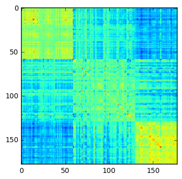

```python
from matplotlib import pyplot as plt
plt.imshow(Cov)
plt.show()
```

The following computes F-scores for individual ANOVAs for each variable by class. If you get finished early try to figure out what's going on.

```python
N = np.array([(X[:,0] == i+1).sum() for i in range(3)])
V = np.array([X[X[:,0] == i+1,1:].var(axis=0) for i in range(3)])
M = np.array([X[X[:,0] == i+1,1:].mean(axis=0) for i in range(3)])
Bvar = (((M - X[:,1:].mean(axis=0))**2.).T * N).sum(axis=1) / 2
Wvar = (V.T * (N-1)).sum(axis=1) / (n - 3)
F = Bvar / Wvar
```

[output not shown]

```python
print F
```

[output not shown]